# Random Variables and Distributions

September 2nd, 2021

## Random Variables

Random variables, say $X$, are variables whose possible values (state space) are drawn from some random phenomenon.

- Tossing a coin
- Rolling a die

There are two types of random variables:

- Discrete
- Continuous

Mostly, discrete random variables will be used in this course.

### Population vs. Sample

Consider some column vector $D$ from a random variable $X$.

We can assume that the observed data is a random sample drawn from $X$, each $x_{i}$ is iid (independently and identically distributed)

In general, the distribution from which $X$ is drawn, as well as its moments. We have the sample, and from the sample we can derive its distribution and moments. Hopefully they are close to the population distribution and moments.

### Histograms

Suppose we have a discrete variable $X$ that can take the values 1, 2, 3, 4 with the following probabilities:

- $1$: $0.2$
- $2$: $0.3$
- $3$: $0.4$
- $4$: $0.10$

Then the probability mass function can be described by the following histogram (which is essentially the probability mass function):

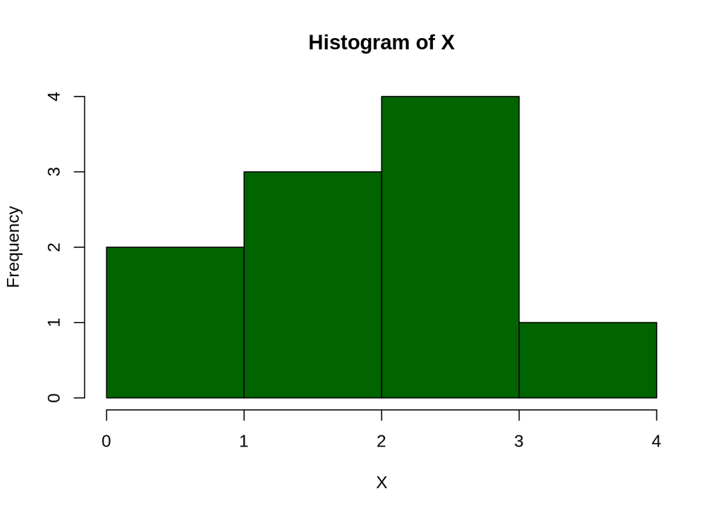

And this equation:

$$\hat{f}(x) = P(X = x) = \frac{1}{n} \sum_{i=1}^{n} I(x_{i} = x)$$

Where $I$ is the identity function:

$$I(x_{i} = x) = \begin{cases}
1 & \text{if } x_{i} = x \\
0 & \text{if } x_{i} \neq x \\
\end{cases}$$

In other words, the $\hat{f}(x)$ function maps all elements in the state space of $X$ to a 1 or 0, depending on whether the element is equal to $x$. It then takes the sum, which is just the number of elements that are equal to $x$. This is similar to how we can sum logical values in R

```r
values <- c(1, 1, 2, 2, 2, 3, 3, 3, 3, 4)
# There are 2 1s in the values vector
sum(values == 1)
```

```
## [1] 2
```

### Probability Density Function

A probability density function (PDF) is similar to a probability mass function (PMF), but it is for continuous random variables.

A density plot visualizes the underlying probability distribution of some data by drawing a continuous curve.

## Measures of Central Tendency

### Mean

Mean (sample):

Is the mean robust/stable? Robustness meaning the measure is not affected by extreme values.

- Not really, an extreme number can impact the mean.
- Rather, a *trimmed mean* can be used, whose extreme values are discarded.

Expectation of an r.v., what’s the difference between the expected value and the mean?

```r
# Suppose we are rolling a die
x <- c(1, 2, 3, 4, 5, 6)
# The probability of rolling any of them is 1/6
probabilities <- rep(1/6, each = 6)

# What is the average value of the die in the long run? (This is the expected value)
expected_value <- 0
for (i in 1:length(x)) {
    expected_value <- expected_value + (x[i] * probabilities[i])
}
print(paste("Expected value:", expected_value))
```

```
## [1] "Expected value: 3.5"
```

```r
# Now suppose we roll the die just 10 times, what is the average? (This is the mean)
rolls <- c(5, 2, 6, 2, 2, 1, 2, 3, 6, 1)
print(paste("Mean: ", mean(rolls)))
```

```
## [1] "Mean:  3"
```

Notice that the mean does not equal the expected value, the mean is some average of a number of observations. The expected value is the average in the long run.

Properties of expectation:

- $E[X+Y] = E[X] + E[Y]$ (Linearity of expectation)
- $E[aX] = aE[X]$ (where $a$ is a constant)
- $E[XY] = E[X] * E[Y]$ (iff $X$ and $Y$ are iid)
- $E[E[X]] = E[X]$

### Median

Median (sample):

$$P(X \leq m) \geq \frac{1}{2} \text{ and } P(x \geq m) \geq \frac{1}{2}$$

Is the median stable? **Yes**, it isn’t affected by extreme values, and it’s an actual value that the random variable takes.

### Mode

Mode is the value at which the PMF attains its maximum value (which value appears the most).

Not really a useful measure of central tendency, since it doesn’t really tell you about the center.

## Measures of Dispersion

Measures of dispersion includes variance and standard deviation:

- Variance: this tells us how much values of $X$ deviate from the expected value of $X$.
- Sample variance: $var(X) = \sigma^{2} = \frac{1}{n - 1} \sum_{i = 1}^{n} (x_{i} - \hat{\mu})^{2}$
- Sample standard deviation is the squared root of the sample variance

## Other measures of central tendency

Maximal deviation and Mean absolute deviation

$$mad(X) \leq stddev(X) \leq maxdev(X)$$

## Multivariates?

If we have two random variables $X_{1}$ and $X_{2}$, how do we find the measures of central tendency for them?

Geometrically, we can view the random variables in n-D space as column vectors.

The first and second moments (mean and variance respectively) can be computed in the same manner, but a *vector* is returned.

- The variance can be computed for *each* attribute, $\sigma_{1}^{2}$ for $X_{1}$ and $\sigma_{2}^{2}$ for $X_{2}$.
- The total variance is given by $var(D) = \sigma_{1}^{2} + \sigma_{2}^{2}$.

## Covariance and Correlation

Measure of association: **Covariance**

Covariance is the measure of association or linear dependence between two variables $X_{1}$ and $X_{2}$:

$$cov(X_{1}, X_{2}) = \hat{\sigma}_{12} = \frac{1}{n - 1} \sum_{i = 1}^{n} (x_{i1} - \hat{\mu_{1}}) * (x_{i2} - \hat{\mu_{2}})$$

A covariance matrix is one whose dimensions are n by n, where $n$ is the number of random variables. A value at row $i$ and column $j$ represents the covariance between random variables at column $i$ and at column $j$. This means across the diagonal of the covariance matrix is just the variance of the particular random variable, as $i = j$ across the diagonal.

The variance of a covariance matrix is understood to be the sum of the diagonal (or the sum of the variances of the random variables). This is also called a trace, as well as the total variance.

Releated to covariance is **correlation**.

Correlation between two variables, $X_{1}$ and $X_{2}$ is the *standardized covariance* obtained by normalizing the covariance with the standard deviation of each variable.

Why do we have both covariance and correlation then?

- The range of covariance: $[ - \infty , \infty ]$
- The range of correlation: $[-1, 1]$
- Correlation is dimensionless

And of course, correlation != causation.

### Collinearity

- Correlation measures the relationship between two variables
- Collinearity occurs when the two variables are so highly correlated that we can use one to predict another; i.e.o, one variable is a linear combination of the other variable.
  - Multicollinearity occurs when > 2 predictor variables are inter-correlated

## Distributions

### Gaussian Distributions

Also known as normal distributions

- Parameterized by mean ($\mu$) and standard deviation ($\sigma$)
- mean = median = mode
  - 68% of the data resides within 1 standard deviation of the mean
  - 95% of the data resides within 2 standard deviations of the mean
  - 99.7% of the data resides within 3 standard deviations of the mean

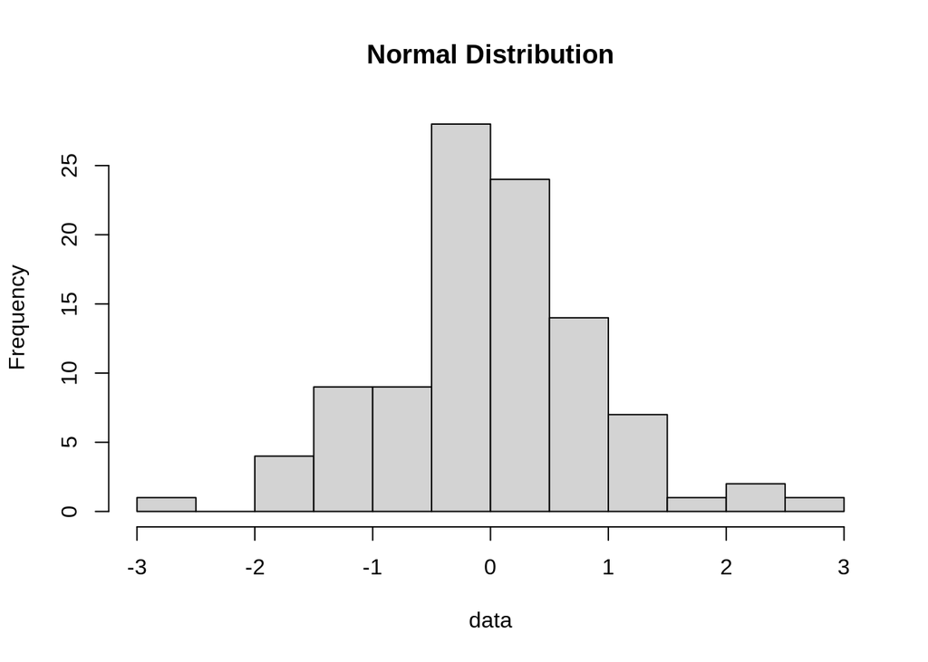

```r
# Sample of 100 normally distributed numbers
data <- rnorm(100)
hist(data, main = "Normal Distribution")
```

### Binomial Distributions

Binomal distributions are parameterized by the *number of trials* $n$ and *probability of success in each trial* $p$

- The PMF is given by observing $x$ successes in $n$ trials: ${}^{n}C_{x} p^{x} (1 - p)^{n - x}$
- Mean: $np$
- Median: $\lfloor np \rfloor$ or $\lceil np \rceil$
- Variance: $np * (1-p)$

### Poisson Distribution

Expresses the probability of a given number of events $k$ occurring in a fixed interval of time if the events occur with a known constant mean rate $\lambda$ and independently of the time since the last event (memoryless property).

- Mean = variance = $\lambda$

### Power-law Distributions

Relationships where one quantity varies as a power of another (Example: area of square quadruples where length is doubled).

## Graphs

### X-Y plots

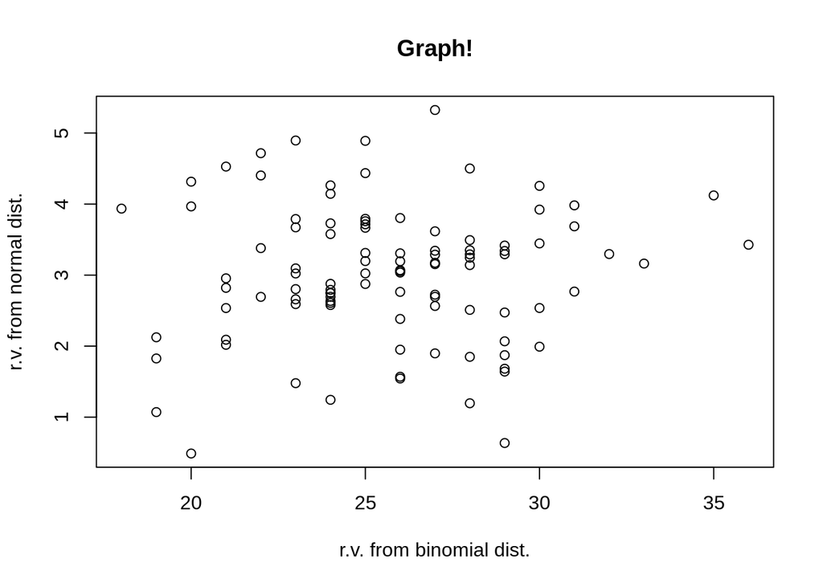

```r
a <- rbinom(100, 50, 0.5)
b <- rnorm(100, 3.0, 1.0)
plot(a, b, xlab="r.v. from binomial dist.", ylab = "r.v. from normal dist.", main = "Graph!")
```

### Boxplots

Boxplots: These tell us 5-number summaries (min, first quartile, median, third quartile, max).

- IQR is the distance between the first and third quartile

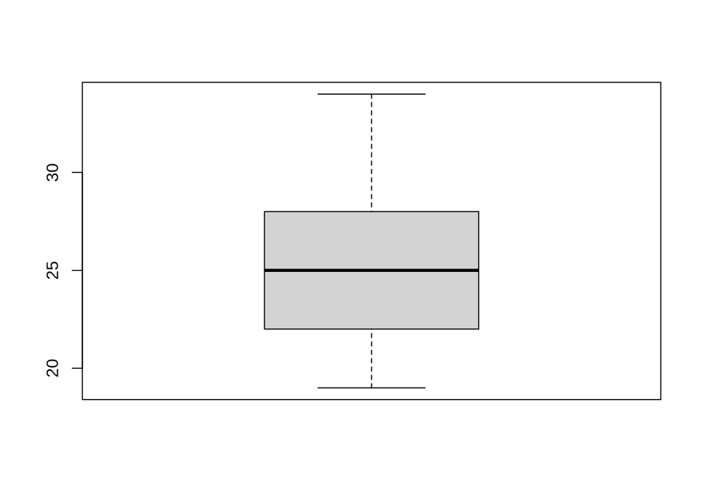

```r
a <- rbinom(100, 50, 0.5)
boxplot(a)
```

### Cumulative Distribution Function (CDF)

- Example: $CDF(X, 15)$ tells us how much percent of the data is less than 15
- If $X = [2, 7, 8, 9, 10, 15, 16, 20]$, then $CDF(X, 15) = \frac{6}{8} = 0.75$

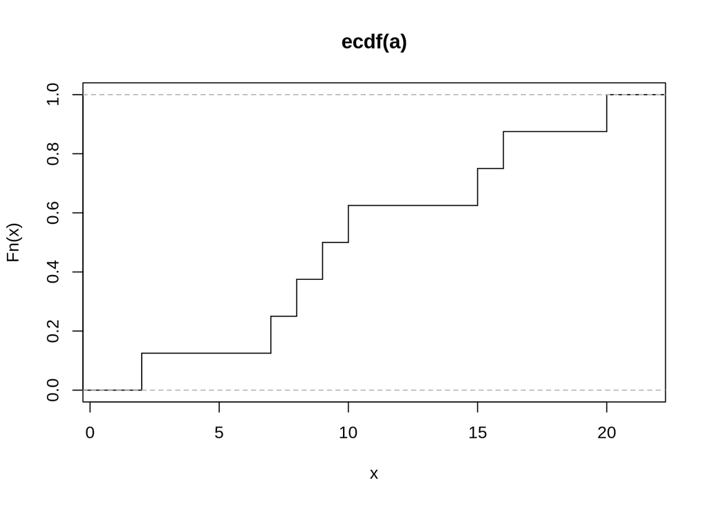

```r
a <- c(2, 7, 8, 9, 10, 15, 16, 20)
plot(ecdf(a), verticals = T, do.points = F)
```

- The derivaive of the CDF is the PDF (makes sense as CDF is the area under the curve of the PDF)

## Debugging in R

- Isolate the problem as best as you can
- Reproduce the problem on a small dataset
- Debugging is an art, it takes time to become proficient at it